# Replication of Faber’s A Quantitative Approach to Tactical Asset Allocation - Asset Class Returns

#### Importing the data into R

Each asset’s class price series has been saved as a CSV. The packages used for performance analysis and backtesting require the data to be xts objects which are created by the following code.

```r
#remove past data
rm(list = ls(envir = globalenv()),envir = globalenv()) #clear Vars from global enviroment
#Load required packages
library(PerformanceAnalytics)
library(quantstrat)
#Set Symbols
symbols <- c("RiskFree","DomesticEquity","GlobalEquity","FixedIncome","Commodities","RealEstate","CPI")
#Import saved pricing data csv files as xts
getSymbols(symbols,
           src = "csv",
           dir="../Data/CSV files/SA/",
           col.names=c("Close"))
```

```
[1] "RISKFREE"       "DOMESTICEQUITY" "GLOBALEQUITY"   "FIXEDINCOME"    "COMMODITIES"    "REALESTATE"     "CPI"
```

#### Calculating asset class returns and charting

Once the data is loaded i can create one xts object for the prices and calculate each asset class’s returns. The asset class returns are then charted.

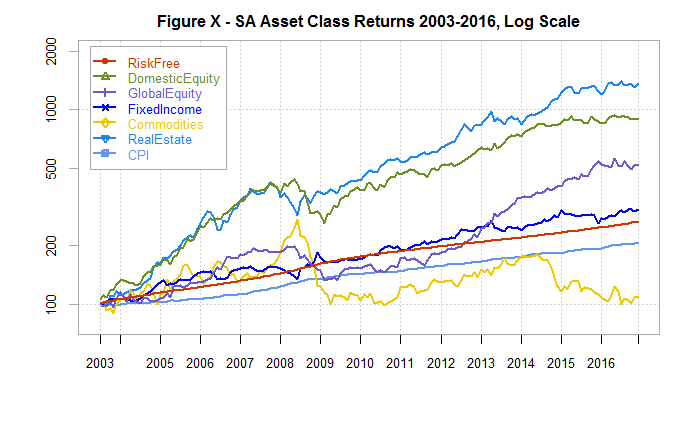

```r
AllAssets <- cbind.xts(Cl(RISKFREE),
                       Cl(DOMESTICEQUITY),
                       Cl(GLOBALEQUITY),
                       Cl(FIXEDINCOME),
                       Cl(COMMODITIES),
                       Cl(REALESTATE),
                       Cl(CPI))
#subset to required period
SubsetPeriod <- "2003-06-30::2016-12-31"
AllAssets <- AllAssets[SubsetPeriod]
colnames(AllAssets) <- symbols
#calculate returns and cum returns
AllAssets.ret <- Return.calculate(AllAssets)[-1,]
AllAssets.cumret <- 100*cumprod(1+ ROC(AllAssets, type = "discrete")[-1,])
chart.TimeSeries(AllAssets.cumret[SubsetPeriod],
 main = paste("Figure X - SA Asset Class Returns ",substr(SubsetPeriod,1,4),"-",substr(SubsetPeriod,13,16),", Log Scale",sep = ""),
 ylab = "",
 ylog = TRUE,
 ylim = c(80,2000),
 date.format = "%Y",
 major.ticks = "years",
 legend.loc = "topleft",
 colorset = c("orangered3","olivedrab","slateblue","blue","gold2","dodgerblue2","cornflowerblue"),
 minor.ticks =FALSE)
```

#### Analysing asset class returns, max drawdowns and other performance statistics

Using the package performance analytics, common performance statistics such as CAGR, volatility and sharpe ratios can be calculated.

```r
#subset to required dates
#SubsetPeriod <- "1972-12-31::2012-12-31"
#Create xts for Returns
Returns <- AllAssets.ret[SubsetPeriod]
#calculate statistics and store as "stats"
stats <- rbind(100*Return.annualized(Returns,scale = 12),
               100*StdDev.annualized(Returns,scale = 12),
               SharpeRatio.annualized(Returns,Rf = AllAssets.ret$RiskFree),
               100*maxDrawdown(Returns,scale = 12,invert = FALSE),
               100*c(Return.annualized(Returns$CPI,scale = 12)))
#rename table rows/column names and format
colnames(stats) <- symbols
rownames(stats) <- c("Return","Volatility",paste("Sharpe (",round(stats[1,"RiskFree"],2),"%)", sep = ""),"MaxDD","Inflation CAGR")
stats <- round(stats[,-7],2)
```

Lets print the stats:

```
               RiskFree DomesticEquity GlobalEquity FixedIncome Commodities RealEstate
Return             7.49          17.63        12.97        8.65        0.73      21.34
Volatility         0.53          15.17        14.33       10.27       23.17      16.35
Sharpe (7.49%)     0.00           0.62         0.36        0.11       -0.27       0.79
MaxDD              0.00         -40.44       -33.39      -14.44      -64.08     -31.87
Inflation CAGR     5.48           5.48         5.48        5.48        5.48       5.48
```

#### Managing Risk

Lets chart each asset with its 10 month simple moving average

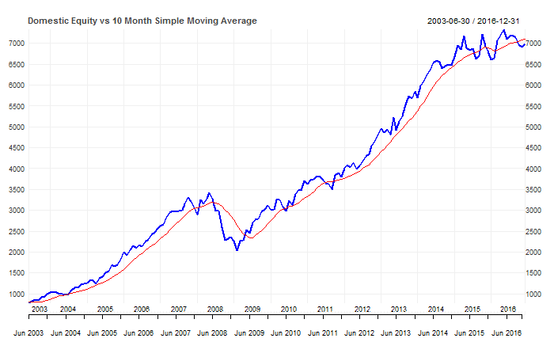

```r
myChart_Theme <- chart_theme() #Create a chart_theme
myChart_Theme$col$line.col <- "blue"
SMAperiod <- 10
chart_Series(Cl(DOMESTICEQUITY),
  name = paste("Domestic Equity vs 10 Month Simple Moving Average",sep = ""),
  theme=myChart_Theme,
  type = "line",
  subset = SubsetPeriod,
  TA = 'add_SMA(n=SMAperiod, on=1, col="red")'
  )
```

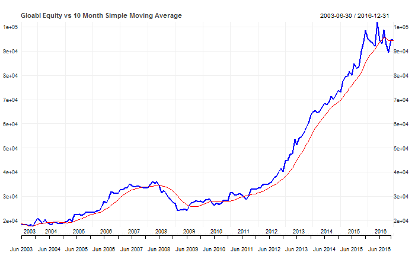

```r
chart_Series(Cl(GLOBALEQUITY),
  name = paste("Gloabl Equity vs 10 Month Simple Moving Average",sep = ""),
  theme=myChart_Theme,
  type = "line",
  subset = SubsetPeriod,
  TA = 'add_SMA(n=SMAperiod, on=1, col="red")'
  )
```

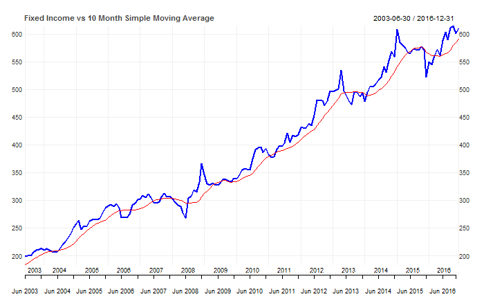

```r
chart_Series(Cl(FIXEDINCOME),
  name = paste("Fixed Income vs 10 Month Simple Moving Average",sep = ""),
  theme=myChart_Theme,
  type = "line",
  subset = SubsetPeriod,
  TA = 'add_SMA(n=SMAperiod, on=1, col="red")'
  )
```

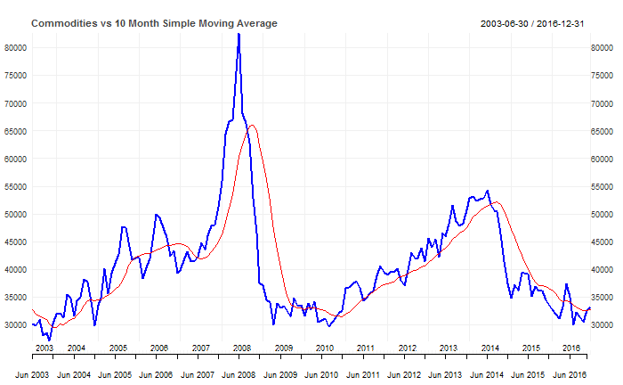

```r
chart_Series(Cl(COMMODITIES),
  name = paste("Commodities vs 10 Month Simple Moving Average",sep = ""),
  theme=myChart_Theme,
  type = "line",
  subset = SubsetPeriod,
  TA = 'add_SMA(n=SMAperiod, on=1, col="red")'
  )
```

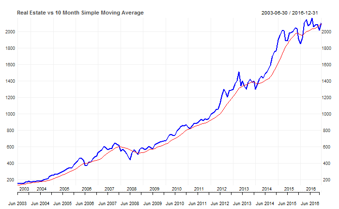

```r
chart_Series(Cl(REALESTATE),
  name = paste("Real Estate vs 10 Month Simple Moving Average",sep = ""),
  theme=myChart_Theme,
  type = "line",
  subset = SubsetPeriod,
  TA = 'add_SMA(n=SMAperiod, on=1, col="red")'
  )
```

#### Calculating returns

```r
#Import saved pricing data csv files as xts
getSymbols("RiskFreeYields",
           src = "csv",
           dir="../Data/CSV files/SA/",
           col.names=c("Close"))
```

```
[1] "RISKFREEYIELDS"
```

```r
#load an additional library
library(dplyr)
#Create new all assets
AllAssets <- cbind.xts(Cl(DOMESTICEQUITY),
                       Cl(GLOBALEQUITY),
                       Cl(FIXEDINCOME),
                       Cl(COMMODITIES),
                       Cl(REALESTATE),
                       Cl(RISKFREEYIELDS))
AllAssets <- AllAssets[SubsetPeriod]
#create dataframe - tidyverse not compatible with xts?
AllAssets.df <- data.frame(date=index(AllAssets), coredata(AllAssets)) #, row.names = index(AllAssets))
#mutate new columns
AllAssets.df  <- mutate(AllAssets.df,
  "10mSMA" = rollmean(Asset.Close,10,fill = 0,align = "right"),
  "Asset.ret" = c(0,diff(Asset.Close)/lag(Asset.Close)[-1]),
  "Rf.ret" = lag((TBILLYIELDS.Close/100)/12),
  "signal" = lag(ifelse(Asset.Close>`10mSMA`,1,0)),
  "Timing.ret" = ifelse(signal == 1,Asset.ret,Rf.ret)
)
```

```
Error: object 'Asset.Close' not found
```

#### Performance Charts

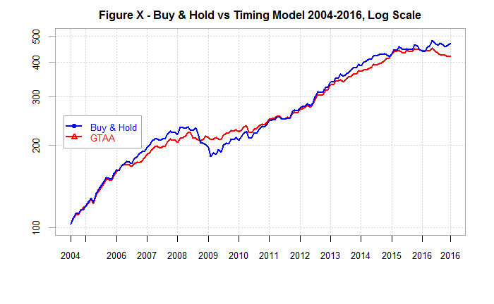

```r
SubsetPeriod <- "2004-06-30::2016-12-31"
Returns <- cbind.xts(AllAssets.xts$BUYANDHOLD.ret,AllAssets.xts$GTAA.ret)[SubsetPeriod]
CumReturns <- 100*cumprod(1+Returns[-1,])
colnames(CumReturns) <- c("Buy & Hold","GTAA")
chart.TimeSeries(CumReturns["1973-01-31::2016-12-31"],
  main = paste("Figure X - Buy & Hold vs Timing Model ",substr(SubsetPeriod,1,4),"-",substr(SubsetPeriod,13,16),", Log Scale",sep = ""),
  date.format = "%Y",
  colorset = c(4,2),
  ylab = "",
  ylog = TRUE,
  ylim = c(100,500),
  legend.loc = "left",
  major.ticks = "years",
  minor.ticks = FALSE)
```

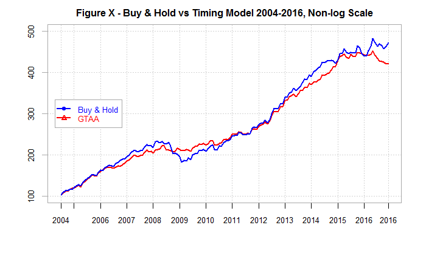

```r
chart.TimeSeries(CumReturns["1973-01-31::2016-12-31"],
  main = paste("Figure X - Buy & Hold vs Timing Model ",substr(SubsetPeriod,1,4),"-",substr(SubsetPeriod,13,16),", Non-log Scale",sep = ""),
  date.format = "%Y",
  colorset = c(4,2),
  ylab = "",
  ylog = FALSE,
  ylim = c(100,500),
  legend.loc = "left",
  major.ticks = "years",
  minor.ticks = FALSE)
```

need proper yield curve! how does this compare to USA?

```r
round(stats,2)
```

[output not shown]

so better sharpe? [confirm calc method/fix interest rate… should i calc manually?] and less maxdd whats kurtosis, information ratio, skew. ask what metrics rad, mb and emyln use… run on longer dater in asset allocation ratios

last 12 months, 3 years, etc returns

rolling returns

to do:

- how to calculate dailyreturns with NA
- check returns make sense - effect of zar?
- compare to US / JPY
- create RF to get 2002 in

To do: SA assets Daily drawdowns Relative performance / rolling perofrmance / alpha 10 worst periods / 10 best periods